# Coursework Report

*N* removed NAs: 3

*N* removed typo: 1

*N* removed <18: 17

*N* total clean: 129

| Group | *N* | *M*<sub>age</sub> | *M*<sub>rating</sub> |
| --- | --- | --- | --- |
| Control | 60 | 21.10 | 5.14 |
| Experim | 69 | 20.72 | 6.41 |

**Main analysis results**

*t*(127) = -9.84, *p* < .001

[interactive chart not shown]

[figure not shown]

[interactive chart not shown]

# Coursework Report

Analysing Data, Spring 2020

# Methods

## Participants

As part of the replication of the Elliot, 2010 study, data from 150 participants (21 in the original experiment) were collected anonymously. Particularly, from the initial number of 150 participants mentioned above, 21 were excluded due to unethical and unreported (N/A) values of age leading to a final sample of 129 participants ranging from 18 to 29 years (*M*<sub>age</sub> = 20.9, *SD*<sub>age</sub> = 1.91). Additionally, there was a reported mean age of 21.10 years in the control group condition (*M*<sub>age</sub> = 21.10, *SD*<sub>age</sub> = 1.98, *N* = 60, % = 46.51) and 20.72 years in the experimental condition respectively (*M*<sub>age</sub> = 20.72, *SD*<sub>age</sub> = 1.84, *N* = 69, % = 53.49).

Table 1 *Descriptive statistics by Condition*

| Condition | *N* | % | *M*<sub>age</sub> | *SD*<sub>age</sub> |
| --- | --- | --- | --- | --- |
| control | 60 | 46.51 | 21.10 | 1.98 |
| experimental | 69 | 53.49 | 20.72 | 1.84 |

## Design

Identically to the original study, the present research aimed to investigate whether colour and specifically the colour has any effect on the perceived attractiveness of males while viewed by women. The main research question/conceptual hypothesis formulated within this context was whether colour influence attractiveness.

All of the participants were randomly allocated to one of the two independent categorical/factor colour variable conditions including, an experimental condition where participants (*N* = 69, % = 53.49) viewed a black-and-white photo of a man on a red background (level 1), and a control condition where participants (*N* = 60, % = 46.51) viewed a similar black-and-white photo on a white background (level 2). In both of the conditions, participants viewed the photo for 5 s and then reported their perceptions of the man’s attractiveness.

Perceived attractiveness was measured in the form of a continuous/rating variable using three face-valid items including, “How attractive do you think this person is?”, “How pleasant is this person to look at?” and “If I were to meet the person in this picture face to face, I would think he is attractive”. All of the items were rated using three 9-point scales ranging from, 1 (not at all attractive) to 9 (extremely attractive).

In this matter, a high score as averaged from the three rating scales in one of the conditions as compared to the other would indicate an increase in attractiveness when either the red or white colour frame is used, meaning that people in the two experimental conditions represent samples from different populations with different mean attractiveness ratings. In contrast, a low averaged score or no significant rating difference between the red and white conditions would indicate no influence of colour in perceived attractiveness and a conclusion that participants in both of the experimental conditions of the study belong in the same population, which has a single mean attractiveness rating.

The operational hypothesis stated in this case, is: “Does viewing a different colour frame around an image of a moderately attractive man influence the mean ratings of his attractiveness?” To answer this statement, an independent measures t-test will be conducted to determine the significance of the results by comparing the means of the two colour groups.

# Results

As a way to accurately report and interpret the data, the composite score of the three rating scales ranging from, 1 (not at all attractive) to 9 (extremely attractive) was calculated. This, allowed for a means plot to be created with the *y*-axis representing the Mean Attractiveness Rating ranging from 0 to 8 and the *x*-axis being the representative of each composite score by colour condition (control, experimental).

Observing the general pattern of results of the graph, the experimental colour condition seems to display a higher mean of attractiveness rating as compared to the control group. In other words, the experimental group displayed a higher composite score on the three 9-point attractiveness scales, possibly indicating that colour red had a stronger effect on the perceived attractiveness of men than white. More specifically, the experimental condition ratings resulted in a mean total of 6.4 (*M* = 6.4) in attractiveness ratings while the control group resulted in a mean total of 5.14 (*M* = 5.14) which is a mean difference of 1.26 (*D* = 1.26) in attractiveness ratings.

An independent measures *t*-test was conducted to determine the significance, or non-significance of the results by comparing the means of the two colour groups and investigating any potential statistical difference in liking. Based on the test results, the means between the two conditions were fairly different, (*M*<sub>diff</sub> = -1.26, 95% CI [-1.51, -1.01]) and there was a significant difference between the two groups on the ratings of liking (*t* (127) = -9.84, *p* = < .001), meaning that colour red had a significant influence (*M* = 6.4) on the attractiveness ratings of men when viewed by women compared to the control group (*M* = 5.14).

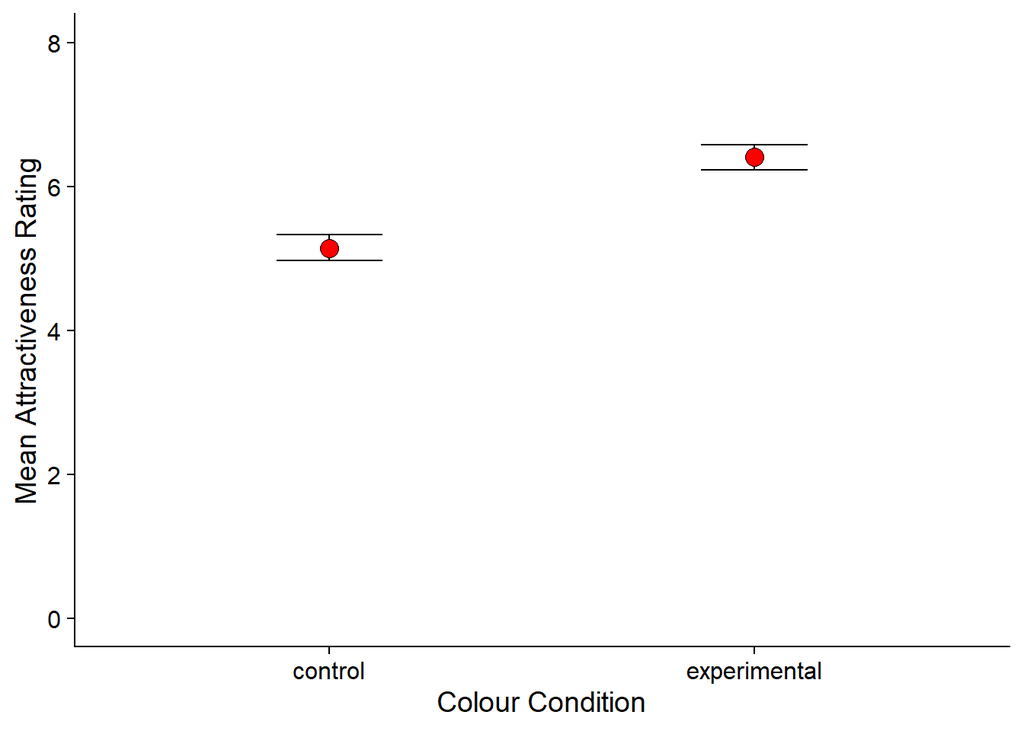

# Discussion

Overall, the experiment conducted provide strong support for the effects of different pigmentations and the hypothesized red effect. The colour red in particular had outstanding effects in increasing men’s sexual desirability with participants in the experimental condition reporting a higher average of scale rates in the three face items/questions compared to the control condition where white was the prominent factor variable. Importantly, this effect was shown both in the descriptive and inferential statistics with the the latter indicating a significant difference between the two groups on liking rates. Operationalization wise, viewing a different colour frame around an image of a moderately attractive man had a significant influence on the mean ratings of his attractiveness. These results, come to support the conceptual hypothesis and research question of the investigation of whether colour influences attractiveness by clearly demonstrating the influence of red on perceptions of attractiveness.

As with regards to the implication of the current investigation to past research conducted, it is firstly important to evaluate and explore the extent to which the current pattern of results relates to the one reported in the original study. In this aspect, it is important to note that both of the studies revealed a significant color effect, with the selected target being rated as more attractive in the experimental condition with red as the dominant colour frame. (Elliot, 2010) Alternatively stated, in both of the experiments participants in the red conditions, compared with those in the white condition, rated the target man an more attractive, providing strong evidence on the effects of colour on attractivess. Even so, despite the similarity of the findings between the present and the original study there are some differences within the replication that may have changed some aspects and further conclusions of the investigation. For example, the number of the participants used in the present and original experiment is numerically unequal with the present experiment obtaining a significantly higher number (*N* = 129) compared to those of the original investigation (*N* = 22). The higher number obtained in the present experiment in this case, may increase the possibility of generalization of the findings to a targeted population of women compared to the original where a minimum number of people were included.

Similarly, other research in this area has investigated the effects of colour in different settings and by utilizing a variety of materials. In a similar setting as the one used in the Elliot, 2010 Experiment 1, Elliot and Niesta, 2008 conducted an experiment where men were asked to rate pictures of moderately attractive women in an assortment of different colour backgrounds and clothing and then asked to report the perceived attractiveness using a scale from 1 (not at all attractive) to 9 (extremely attractive). Analyses revealed a significant effect of colour and participants in the red condition rated the target woman as more attractive than did those in the white condition. (Elliot & Niesta, 2008) These results support the findings of the current study by using a similar methodology and materials and showing a significant effect on the perceived attractiveness. The switch to focus on the perveived attractiveness of women among men is equally worth-mentioning as it provides a new perspective within the context of the present study. Further, the study clearly indicates the influence of colour (either displayed on a background or clothing) on perceived attractiveness, coming to provide support on the conceptual hypothesis of the current investigation. If future research was meant to be conducted in this case, different colour stimuli, such as clothes could be possibly used. Finally, using women photos instead of male one’s could also be an intresting change to explore by equally integrating a sociocultural aspect within the literature (the beauty stereotype of a woman in a red dress).

Contrasting perspectives to the current study, however are also prominent. Hesslinger, Golfbach & Carbon, 2015 conducted a replication of the Elliot et al., 2010 first experiment by presenting the same photo of the man in either a red or white background and asked participant to report perceived attractiveness using an identical rating scale. A second experiment was also conducted where women were presented with photos of multiple men dressed in either formal or casual apparel styles, again in a similar setting with either red or white present. As the results showed, there was no significant impact of red in either of the studies. (Hesslinger, Golfbach & Carbon, 2015) These findings, come to contrast the research question of the present study by showing no effect of the red colour or white colour on perceptions of attractiveness among women. It is also important to mention that the researchers attributed the non-constant results of this replication to a lack of ecological validity of Elliot et al.’s findings by equally questioning the robustness of the experiment. Based on, this it could be assumed that running the experiment in a different setting such as a field experiment or a focus group (examining perceptions of attractiveness with relation to different colours) could possibly provide more ecological valid results.

Additional possible limitations with the use of this type of design have also being addressed in a variety of other studies which support that the red effect could be limited if it emerged with an exposure time of less than 5 s. (Paperkoorn, Roberts & Pollet, 2016) Future research should determine the duration of the effect, especially in circumstances where viewing time overpasses the 5 s. Similarly it could be argued that the use of a single male target may not be a trustworthy number by ignoring individual variablity and specifically, the participants mating preferences. Particularly, testing with a larger number of picture could possibly lead to more valid and reliable results by increasing the diversity of the targets. Finally, it would be really informative for future research to examine the effect of colours such as red among different sociocultural settings, approaching in this way the research holistically.

Coming to an end, the effects of colour, and specifically of colour red, on the perceptions of attractiveness both among men and women have been investigated in a large amount of studies with contradicting findings making this field of research rather unclear and diverse. In line with Elliot et al. 2010, the present study displayed a consistency in those findings, by clearly indicating the effect of red on perceived attractiveness. Nevertheless, provided the ambiguity of the evidence more research on this topic should be conducted as the only way leading us closer to more precise and reliable conclusions.

# References

Elliot, A. J., Kayser, D. N., Greitemeyer, T., Lichtenfeld, S., Gramzow, R. H., Maier, M. A., & Liu, H. (2010). Red, rank, and romance in women viewing men. Journal of Experimental Psychology. General, 139(3), 399–417.

Elliot, A. J., & Niesta, D. (2008). Romantic red: red enhances men’s attraction to women. Journal of Personality and Social Psychology, 95(5), 1150–1164.

Hesslinger, V. M., Goldbach, L., & Carbon, C.-C. (2015). Men in red: A reexamination of the red-attractiveness effect. Psychonomic Bulletin & Review, 22(4), 1142–1148.

Peperkoorn, L. S., Roberts, S. C., & Pollet, T. V. (2016). Revisiting the Red Effect on Attractiveness and Sexual Receptivity: No Effect of the Color Red on Human Mate Preferences. Evolutionary Psychology: An International Journal of Evolutionary Approaches to Psychology and Behavior, 14(4), 1474704916673841.